# Spotify API - Student Tutorial

*Jeremy Sapienza X81000498*

**Spotify** è un servizio musicale che offre lo streaming on demand di una selezione di brani di varie case discografiche ed etichette indipendenti, incluse Sony, EMI, Warner Music Group e Universal.

La musica può essere visualizzata per artista, album, etichetta, genere o playlist così come grazie a ricerche dirette. Sui dispositivi desktop un collegamento permette all'ascoltatore di acquistare materiale selezionato presso venditori di terze parti.

Esiste una **versione gratuita e a pagamento** della piattaforma, nella maggior parte dei paesi dell'Europa, nella quasi totalità delle Americhe, in Australia, in Nuova Zelanda e in alcuni paesi dell'Asia. Il servizio è fruibile attraverso Microsoft Windows, macOS, GNU/Linux e molti altri dispositivi mobile.

Spotify quindi prevede due tipologie di utenze:

1. **Free**, già disponibile al momento della sottoscrizione del servizio accedendo con un account Facebook o Spotify, con la quale l'utente può ascoltare una quantità illimitata di musica, ma sovrapposta a pubblicità visiva e simil-radiofonica e con possibiltà di passare da un brano all'altro della playlist sei volte in un'ora;
2. **Premium**, che consente di ascoltare musica senza interruzioni pubblicitarie ed accedere ad ulteriori funzioni come lo streaming con maggiore bitrate (fino a 320 kb/s) e l'accesso offline alla musica.

Spotify ci permette di poter usufrire della loro API, per ottenere dei dati da poter utilizzare per le nostre analisi quali: posizione in classifica, playlist, genere, mercati di distribuzione della canzone e molto altro ancora.

[figure not shown]

Creiamo un account da sviluppatore dal sito https://developer.spotify.com/; qualora possedessimo un account Facebook o Apple, la registrazione verrebbe velocizzata con un semplice accesso tramite una delle due piattaforme, altrimenti occorrerebbe andare a riportare tutte le informazioni personali.

Una volta creato l'account sviluppatore, abbiamo bisogno di creare un'applicazione, al fine di ottenere le credenziali utili per accedere all'API di Spotify e ottenere di conseguenza il relativo token per l'accesso.

[figure not shown]

Cliccando sul riquadro "My New App", apparirà un modulo di 3 steps in cui andare a riportare:

- Nel **Primo Step**, il nome dell'applicazione, una breve descrizione e dove essa verrà implementata (applicazione mobile, desktop, sito web etc..)
- Nel **Secondo Step**, viene chiesto per quali scopi viene creata l'applicazione per uso **commerciale** o **non-commerciale**
- Nel **Terzo Step**, dopo aver scelto l'uso a fini commerciali o non, viene riportata una schermata relativa all'adesione alle norme introdotte da spotify

[figure not shown]

Dopo aver eseguito i relativi tre steps, accederemo ad un'interfaccia nella quale verranno mostrate: Client ID e Client Secret.

Insieme ad altre credenziali come User ID, Scope e Redirect URL verranno utilizzate per ottenere il token di accesso all'API.

[figure not shown]

Basata su semplici principi REST, gli endopoint dell'API Web di Spotify restituiscono metadati JSON su artisti, album e brani musicali, direttamente dal catalogo dati Spotify.

Per aver accesso ai dati privati, come profili utenti e playlist, l'applicazione che richiede l'accesso a tali dati deve richiedere un permesso di accesso chiamato **Authorization**.

### Come ottenere informazioni per una traccia (esempio)

**Curl**

curl -X GET "https://api.spotify.com/v1/tracks/11dFghVXANMlKmJXsNCbNl" -H "Authorization: Bearer {your access token}"

**Request URL**

https://api.spotify.com/v1/tracks/11dFghVXANMlKmJXsNCbNl

**Track object (not full)**

{ "album": { "album_type": "single", "artists": [ { "external_urls": { "spotify": "https://open.spotify.com/artist/6sFIWsNpZYqfjUpaCgueju" }, "href": "https://api.spotify.com/v1/artists/6sFIWsNpZYqfjUpaCgueju", "id": "6sFIWsNpZYqfjUpaCgueju", "name": "Carly Rae Jepsen", "type": "artist", "uri": "spotify:artist:6sFIWsNpZYqfjUpaCgueju" } ], "available_markets": [ "AD", "AR", "AT", "AU", "BE", "BG", "BO", "BR", "CA", "CH", "CL", "CO", "CR", "CY", "CZ", "DE", "DK", "DO", "EC", "EE", "ES", "FI", "FR", "GB", ...

# Come iniziare?

iniziamo adesso ad elaborare i nostri metadati JSON per poter effettuare delle analisi accurate riguardo determinate caratteristiche come: posizione in classifica, playlist ecc..

In questo tutorial mostriamo come andare ad estrarre e analizzare i dati che ci vengono forniti dalle nostre richieste. Il linguaggio che noi utilizzeremo è **Python3**.

Spotify, inoltre fornisce un elenco di librerie per l'integrazione con l'API Web di Spotify utilizzando diversi linguaggi e piattaforme di programmazione. Nel nostro caso utilizziamo **spotipy**, i creatori della libreria hanno creato una repository su github in cui troviamo molti esempi riguardo l'utilizzo delle funzioni da loro implementate: https://github.com/plamere/spotipy.

Sito di documentazione ufficiale Spotipy: https://spotipy.readthedocs.io/en/2.9.0/

Dopo aver correttamente installato la libreria nel sistema:

- pip install spotipy

aggiungiamo alle variabili d'ambiente del sistema il Client ID e Secret, fornitoci in precedenza:

- export SPOTIPY_CLIENT_ID= 'client_id_here'
- export SPOTIPY_CLIENT_SECRET= 'client_secret_here'

occorre adesso ottenere il token, forniamo dunque alla richiesta:

- **codice** (username), ottenibile andando su Spotify, Account Personale (in alto a destra), Copia Spotify URI (estraiamo il codice personale, visualizzato come spotify:user:codice).
- **scope**, L'insieme di ambiti passati nella chiamata determina le autorizzazioni di accesso che l'utente deve concedere, esempi di ambiti sono: 'playlist-read-private', 'playlist-modify-public', 'user-read-currently-playing' etc..
- **client_id**
- **client_secret**
- **redirect_uri**, la risposta dell'API ci fornisce un token per l'accesso all'API stessa, occorre inserire dalla dashboard dell'applicazione la pagina a cui saremo indirizzati. Nel nostro esempio è google.com, dall'esecuzione infatti si nota che nell'URL della pagina a cui siamo stati condotti è concatenato il nostro token richiesto

```python
import spotipy #library that use api spotify
import spotipy.util as util
from json.decoder import JSONDecodeError

username = '1168261438'
scope = ''
token = util.prompt_for_user_token(username,
                                   scope,
                                   client_id='your_clientid_here',
                                   client_secret='your_clientsecrete_here',
                                   redirect_uri='https://google.com')
```

ci sono **3 metodi** opzionali **di autorizzazione** con cui possiamo ottenere l'autorizzazione dell'app:

- Autorizzazione utente aggiornabile: **Authorization Code**
- Autorizzazione utente temporanea: **Implicit Grant**
- Autorizzazione app aggiornabile: **Client Credentials Flow**

l'autorizzazione dai noi utilizzata è l'*Authorization Code*, questo metodo è adatto per applicazioni di lunga durata in cui l'utente concede l'autorizzazione **una sola volta**. Tale metodo ci fornisce un token di accesso che può essere aggiornato. Poichè lo scambio del token comporta l'invio della propria chiave segreta questo metodo andrebbe eseguito in un luogo sicuro, come un servizio back-end e non da un browser o da un'app mobile.

[figure not shown]

*(in allegato la foto in cui si mostra come funziona tutto il processo di tale autorizzazione)*

```python
from spotipy.oauth2 import SpotifyClientCredentials

if token:
    spotify = spotipy.Spotify(auth = token)
else:
    print("Can't get token for", username)
```

Per eseguire le nostre analisi sui dati, scegliamo di catturare una feature non estraibile direttamente dall'API, poichè essa non fornisce come dato base per la nostra analisi **gli streams** relativi alla traccia in una giornata (nel nostro caso risalienti al 4/3/2020).

Dal sito ufficiale di Spotify, abbiamo scaricato 62 classifiche in cui abbiamo creato un nuovo dataset composto dall'unione di tutte le tuple delle classifiche estratte:

- **Position**, relativo alla posizione in classifica in una data playlist della canzone interessata.
- **Song**, relativo al nome della canzone
- **Artist**, relativo al nome dell'artista della canzone
- **Streams**, numero dei cosiddetti "play" della traccia
- **Markets**, numero dei mercati in cui è distribuita la canzone
- **Genre**, genere della canzone
- **Playlist**, nome della playlist che interessano tutte le precedenti caratteristiche appena descritte

utilizziamo la libreria **os** per andare a leggere ricorsivamente la cartella, catturando volta per volta ciascun mini-dataset inerente ad una particolare classifica, di un paese nel mondo. Utilizziamo invece la libreria **csv** per andare a inserire le tuple interessate per la nostra analisi

```python
import os
import csv

i = 0 #only to show 0 to 61
entries = os.listdir('./Scrivania/ProjectWebAPISpotify/Top 50 - Playlists')
with open('./Scrivania/ProjectWebAPISpotify/dataset.csv', 'a', newline='') as f:
    thewriter = csv.writer(f)

    thewriter.writerow(['Position','Song','Artist','Streams','Markets', 'Genre', 'Playlist'])
    for entry in entries:
        with open('./Scrivania/ProjectWebAPISpotify/Top 50 - Playlists/'+entry) as f:
            readCSV = csv.reader(f)
            for row in readCSV:
                if row[0].isnumeric() == True:
                    name_playlist = entry.replace(".csv",'')

                    ss = spotify.track(row[4])
                    num_markets = len(ss['available_markets']) #number of markets in the world

                    aa = spotify.search(row[2], 1, 0, "artist")
                    if aa['artists']['items'][0]['genres']:   #search the first genre of the artist, not song!
                        found_genre = aa['artists']['items'][0]['genres'][0]
                    else:
                        found_genre = "no genres"

                    thewriter.writerow([row[0],row[1],row[2],row[3],num_markets,found_genre,name_playlist])
print("Dataset Created")
```

```
Dataset Created
```

Dopo essere andati a raccogliere le informazioni, utili per andare ad effettuare la nostra analisi, andiamo a creare il nuovo dataset con caratteristiche nuove, generate dalle informazioni presenti dal precedente dataset ottenuto.

usiamo la libreria **pandas** per andare a manipolare i nostri dati caricati nel dataset di estensione .csv

i valori non risultano essere normalizzati, infatti risulta essere una buona norma andare a **normalizzare** i valori per definire un range più piccolo.

Abbiamo generato nuovi valori ottenuti dal precedente dataset:

- **Artist**, relativo al nome dell'artista della canzone
- **Song**, relativo al nome della canzone
- **Total Stream**, numero totale di streams registrato in tutte le playlist in cui compare la canzone
- **MediumPositionsINTERN**, posizione media della canzone rispetto a dove è inserita nelle playlist
- **MediumPositionsALL**, posizione media della canzone rispetto a **tutte** le playlist esistenti (62 in totale)
- **PresenceIN**, numero di playlist in cui la canzone compare
- **Markets**, numero dei mercati in cui è distribuita la canzone
- **Genre**, genere della canzone

```python
import pandas as pd

data = pd.read_csv("./Scrivania/ProjectWebAPISpotify/dataset.csv") #load the dataframe

new_data = data.groupby(['Artist','Song']).sum()
streams = new_data[['Streams']]
streams = streams.rename(columns={"Streams": "Total Stream"})

new_data = round((data.groupby(['Artist','Song']).mean()),2)
mediumpintern = new_data[['Position']]
mediumpintern = mediumpintern.rename(columns={"Position": "MediumPositionsINTERN"})

new_data = round((data.groupby(['Artist','Song']).mean())/62, 2)
mediumpall = new_data[['Position']]
mediumpall = mediumpall.rename(columns={"Position": "MediumPositionsALL"})

new_data = data.groupby(['Artist','Song']).count()
count = new_data[['Position']]
count = count.rename(columns={"Position":"PresenceIN"})

renamed_dt = pd.concat([streams, mediumpintern,mediumpall,count], axis = 1 )

section_data = data[['Song','Artist','Markets','Genre']]
realdt = pd.merge(renamed_dt, section_data, on = ['Artist','Song'], how = 'inner')
realdt = realdt.drop_duplicates().reset_index(drop=True)
realdt.to_csv('./Scrivania/ProjectWebAPISpotify/realdataset.csv', index=False)

realdt.head(10)
```

|  | Artist | Song | Total Stream | MediumPositionsINTERN | MediumPositionsALL | PresenceIN | Markets | Genre |
| --- | --- | --- | --- | --- | --- | --- | --- | --- |
| 0 | 1.Cuz | FÖRSENT | 51862 | 50.00 | 0.81 | 1 | 79 | swedish gangsta rap |
| 1 | 24kGoldn | CITY OF ANGELS | 330904 | 38.20 | 0.62 | 10 | 79 | cali rap |
| 2 | 47ter | Côte Ouest | 138991 | 24.00 | 0.39 | 1 | 3 | french hip hop |
| 3 | 4Keus | MD (feat. Niska) | 203187 | 9.00 | 0.15 | 1 | 6 | french hip hop |
| 4 | 5MIINUST | Aluspükse | 2254 | 15.00 | 0.24 | 1 | 79 | estonian hip hop |
| 5 | 5MIINUST | Paaristõuked | 4542 | 3.00 | 0.05 | 1 | 79 | estonian hip hop |
| 6 | 5MIINUST | Tsirkus | 1351 | 46.00 | 0.74 | 1 | 79 | estonian hip hop |
| 7 | 831 | 想見你想見你想見你(電視劇"想見你"片尾曲) | 53926 | 12.00 | 0.19 | 2 | 79 | mandopop |
| 8 | A Boogie Wit da Hoodie | Numbers (feat. Roddy Ricch, Gunna and London O... | 643865 | 37.00 | 0.60 | 2 | 78 | melodic rap |
| 9 | A-Lin | 有一種悲傷 - 電影《比悲傷更悲傷的故事》主題曲 | 46831 | 34.67 | 0.56 | 3 | 79 | mandopop |

possiamo andare a rilevare dati come ad esempio:

- la canzone che ha registrato il **minor/alto** numero di streams.
- la canzone che ha registrato il **minor/alto** indice di posizione medio rispetto alle classifiche di **tutto il mondo**.
- la canzone che ha registrato il **minor/alto** numero di volte in cui è comparsa nelle rispettive playlist.

```python
realdt = pd.read_csv("./Scrivania/ProjectWebAPISpotify/realdataset.csv")
realdt.reset_index(drop=True)

#il minor/massimo numero di streaming registrato da una canzone e inserita nelle Top 50 del mondo
max_stream_song = realdt.loc[realdt['Total Stream'].idxmax()]
data = [max_stream_song['Artist'], max_stream_song['Song']]
print("[Max] Stream Song-> ", data[0], "-", data[1])

min_stream_song = realdt.loc[realdt['Total Stream'].idxmin()]
data = [min_stream_song['Artist'], min_stream_song['Song']]
print("[Min] Stream Song-> ", data[0], "-", data[1])

#il minor/massimo indice di posizione medio registrato da una canzone e inserita nelle Top 50 del mondo
max_index_song = realdt.loc[realdt['MediumPositionsALL'].idxmax()]
data = [max_index_song['Artist'], max_index_song['Song']]
print("\n[Max] Position Song-> ", data[0], "-", data[1])

min_index_song = realdt.loc[realdt['MediumPositionsALL'].idxmin()]
data = [min_index_song['Artist'], min_index_song['Song']]
print("[Min] Position Song-> ", data[0], "-", data[1])

#il minor/massimo numero di presenze registrato da una canzone e presente nelle Top 50 del mondo
max_presences_song = realdt.loc[realdt['PresenceIN'].idxmax()]
data = [max_presences_song['Artist'], max_presences_song['Song']]
print("\n[Max] Presences Song-> ", data[0], "-", data[1])

min_presences_song = realdt.loc[realdt['PresenceIN'].idxmin()]
data = [min_presences_song['Artist'], min_presences_song['Song']]
print("[Min] Presences Song-> ", data[0], "-", data[1])
```

```
[Max] Stream Song->  The Weeknd - Blinding Lights
[Min] Stream Song->  Gzuz - Kopfnüsse

[Max] Position Song->  1.Cuz - FÖRSENT
[Min] Position Song->  ALLY - How To Love (feat. GRAY)

[Max] Presences Song->  Tones and I - Dance Monkey
[Min] Presences Song->  1.Cuz - FÖRSENT
```

mostriamo adesso altri **grafici** di visualizzazione dei dati, per vedere a grandi linee l'andamento dei dati a seconda di una particolare situazione da noi decisa.

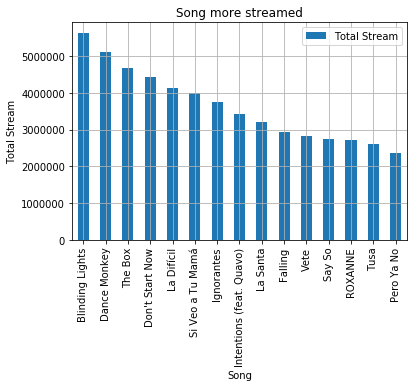

```python
from matplotlib import pyplot as plt
manipulate_dt = realdt

#catching only the 15 songs that obtained more streams at the moment
manipulate_dt = manipulate_dt.set_index('Song').sort_values('Total Stream', ascending=False)
manipulate_dt[['Artist','Total Stream']].head(15).plot.bar()
plt.grid()
plt.xlabel('Song')
plt.ylabel('Total Stream')
plt.title('Song more streamed')

plt.show()
```

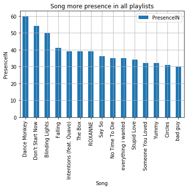

```python
#catching only the 15 songs that are more presenced in all playlists
manipulate_dt = manipulate_dt.sort_values('PresenceIN', ascending=False)
manipulate_dt[['Artist','PresenceIN']].head(15).plot.bar()
plt.grid()
plt.xlabel('Song')
plt.ylabel('PresenceIN')
plt.title('Song more presence in all playlists')

plt.show()
```

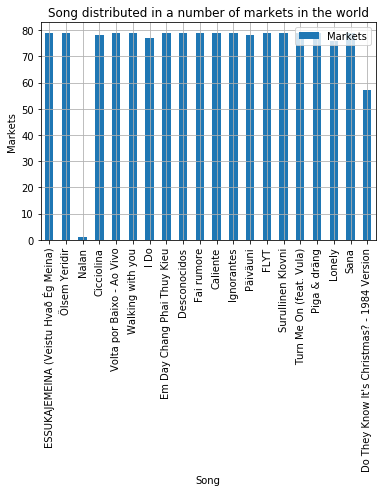

```python
#catching 20 songs random that are distributed in different markets from all the world
manipulate_dt[['Artist','Markets']].sample(n = 20).plot.bar()
plt.grid()
plt.xlabel('Song')
plt.ylabel('Markets')
plt.title('Song distributed in a number of markets in the world')

plt.show()
```

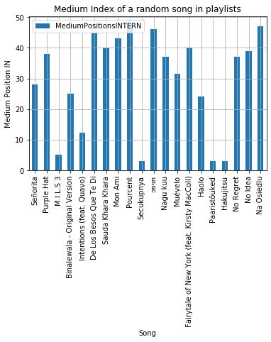

```python
#show 20 Medium positions that the songs obtained in playlists
manipulate_dt[['Artist','MediumPositionsINTERN']].sample(n = 20).plot.bar()
plt.grid()
plt.xlabel('Song')
plt.ylabel('Medium Position IN')
plt.title('Medium Index of a random song in playlists')

plt.show()
```

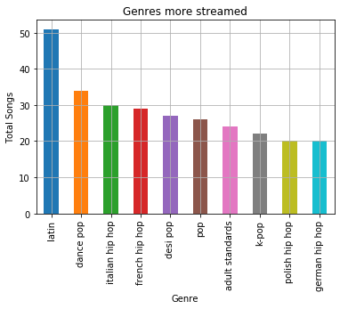

```python
manipulate_dt = manipulate_dt[manipulate_dt.Genre != "no genres"]
manipulate_dt.groupby('Genre')['Artist'].count().sort_values(ascending=False).head(10).plot.bar()
plt.grid()
plt.xlabel('Genre')
plt.ylabel('Total Songs')
plt.title('Genres more streamed')

plt.show()
```

i 10 artisti con più brani nelle classifiche

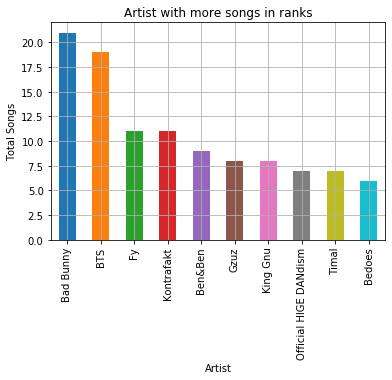

```python
manipulate_dt.groupby('Artist')['PresenceIN'].count().sort_values(ascending=False).head(10).plot.bar()
plt.grid()
plt.xlabel('Artist')
plt.ylabel('Total Songs')
plt.title('Artist with more songs in ranks')

plt.show()
```

Mostriamo alcuni risultati ottenuti in precedenza mediante il grafico a torta, sui i primi tre risultati più promettenti

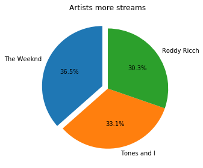

```python
#catching only the 3 songs that obtained more streams at the moment
manipulate_dt = manipulate_dt.sort_values('Total Stream', ascending=False)
three_song = manipulate_dt[['Artist','Total Stream']].head(3)

labels = [three_song.iloc[0][0], three_song.iloc[1][0], three_song.iloc[2][0]]
y = [three_song.iloc[0][1], three_song.iloc[1][1], three_song.iloc[2][1]]
esplodi = [0.1, 0, 0]

fig, ax1 = plt.subplots()
ax1.pie(y, labels=labels, explode=esplodi, autopct='%1.1f%%', startangle=90)
ax1.set_title("Artists more streams")

fig.tight_layout()
```

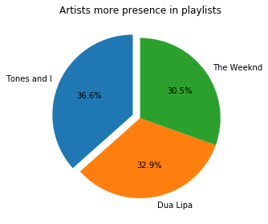

```python
#catching only the 3 songs that are more presences in playlists
manipulate_dt = manipulate_dt.sort_values('PresenceIN', ascending=False)
three_song = manipulate_dt[['Artist','PresenceIN']].head(3)

labels = [three_song.iloc[0][0], three_song.iloc[1][0], three_song.iloc[2][0]]
y = [three_song.iloc[0][1], three_song.iloc[1][1], three_song.iloc[2][1]]
esplodi = [0.1, 0, 0]

fig, ax1 = plt.subplots()
ax1.pie(y, labels=labels, explode=esplodi, autopct='%1.1f%%', startangle=90)
ax1.set_title("Artists more presence in playlists")

fig.tight_layout()
```

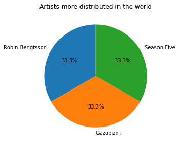

```python
#catching only the 3 songs that are more distributed in all the world
manipulate_dt = manipulate_dt.sort_values('Markets', ascending=False)
three_song = manipulate_dt[['Artist','Markets']].head(3)

labels = [three_song.iloc[0][0], three_song.iloc[1][0], three_song.iloc[2][0]]
y = [three_song.iloc[0][1], three_song.iloc[1][1], three_song.iloc[2][1]]
esplodi = [0, 0, 0]

fig, ax1 = plt.subplots()
ax1.pie(y, labels=labels, explode=esplodi, autopct='%1.1f%%', startangle=90)
ax1.set_title("Artists more distributed in the world")

fig.tight_layout()
```

Prima di effettuare la **regressione lineare multipla**, andiamo a visualizzare la **correlazione** tra i vari **set di dati** presenti nel nostro dataset. Utilizziamo la funzione **heatmap** definita nella libreria **seaborn** per visualizzare graficamente tale relazione

```python
realdt.corr()
```

|  | Total Stream | MediumPositionsINTERN | MediumPositionsALL | PresenceIN | Markets |
| --- | --- | --- | --- | --- | --- |
| Total Stream | 1.000000 | -0.179246 | -0.178955 | 0.876348 | 0.029628 |
| MediumPositionsINTERN | -0.179246 | 1.000000 | 0.999915 | -0.074372 | 0.028698 |
| MediumPositionsALL | -0.178955 | 0.999915 | 1.000000 | -0.073954 | 0.028870 |
| PresenceIN | 0.876348 | -0.074372 | -0.073954 | 1.000000 | 0.036122 |
| Markets | 0.029628 | 0.028698 | 0.028870 | 0.036122 | 1.000000 |

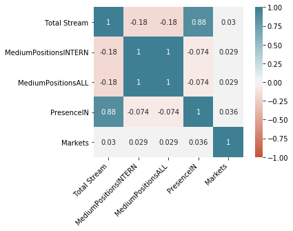

```python
import seaborn as sns
corr = realdt.corr()
ax = sns.heatmap(
    corr,
    vmin=-1, vmax=1, center=0,
    cmap=sns.diverging_palette(20, 220, n=200),
    square=True,
    annot=True
)
ax.set_xticklabels(
    ax.get_xticklabels(),
    rotation=45,
    horizontalalignment='right'
);
```

Notiamo che possediamo un valore alto di correlazione tra tali set di dati:

- **MediumPositionsINTERN e MediumPositionsALL**
- **PresenceIN e Total Stream**

proviamo dunque a creare uno scatterplot che ci faccia vedere effettivamente questa correlazione tra i set di dati appena citati.

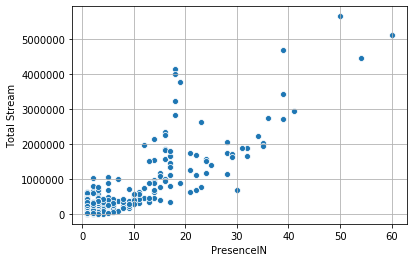

```python
ax = sns.scatterplot(x="PresenceIN", y="Total Stream",data=realdt)
ax.grid()
```

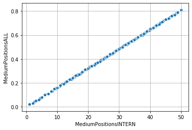

```python
ax = sns.scatterplot(x="MediumPositionsINTERN", y="MediumPositionsALL",data=realdt)
ax.grid()
```

Effettuiamo la **Z-Score** per la **normalizzazione dei dati** perchè la **regressione lineare multipla** non performa bene con dati non normalizzati.

Lo **Z-Score** consiste nel prendere ogni singola tupla del dataset sottrarre il valore di ciascuna feature per la corrispettiva media fratto la deviazione standard. Lo Z-Score viene applicato per le features di valori numerici.

```python
import pandas as pd

dataset = pd.read_csv('./Scrivania/ProjectWebAPISpotify/realdataset.csv')
print(round(dataset.describe(),2)) #get information about dataset, count, mean, std, min, quantil, max..

#Z-Scaling used for normalized the ranges
normalized_dataset = dataset
normalized_dataset[['Total Stream', 'MediumPositionsINTERN', 'MediumPositionsALL', 'PresenceIN','Markets']] = round(((dataset[['Total Stream', 'MediumPositionsINTERN', 'MediumPositionsALL', 'PresenceIN','Markets']] - dataset[['Total Stream', 'MediumPositionsINTERN', 'MediumPositionsALL', 'PresenceIN','Markets']].mean())/dataset[['Total Stream', 'MediumPositionsINTERN', 'MediumPositionsALL', 'PresenceIN','Markets']].std()),2)
print(normalized_dataset.head(10))
print(normalized_dataset[['Total Stream', 'MediumPositionsINTERN', 'MediumPositionsALL', 'PresenceIN','Markets']].head()) #get the first five tuples
print(round(normalized_dataset.describe(),2)) #get information about dataset, count, mean, std, min, quantil, max..
```

```
       Total Stream  MediumPositionsINTERN  MediumPositionsALL  PresenceIN  \
count       1077.00                1077.00             1077.00     1077.00
mean      213363.56                  27.67                0.45        2.88
std       530840.13                  13.84                0.22        6.07
min         1057.00                   1.00                0.02        1.00
25%        14740.00                  16.52                0.27        1.00
50%        62219.00                  29.00                0.47        1.00
75%       160326.00                  40.00                0.65        1.00
max      5640387.00                  50.00                0.81       60.00

       Markets
count  1077.00
mean     73.60
std      18.75
min       1.00
25%      78.00
50%      79.00
75%      79.00
max      79.00
                   Artist                                               Song  \
0                   1.Cuz                                            FÖRSENT
1                24kGoldn                                     CITY OF ANGELS
2                   47ter                                         Côte Ouest
3                   4Keus                                   MD (feat. Niska)
4                5MIINUST                                          Aluspükse
5                5MIINUST                                       Paaristõuked
6                5MIINUST                                            Tsirkus
7                     831                             想見你想見你想見你(電視劇"想見你"片尾曲)
8  A Boogie Wit da Hoodie  Numbers (feat. Roddy Ricch, Gunna and London O...
9                   A-Lin                           有一種悲傷 - 電影《比悲傷更悲傷的故事》主題曲

   Total Stream  MediumPositionsINTERN  MediumPositionsALL  PresenceIN  \
0         -0.30                   1.61                1.63       -0.31
1          0.22                   0.76                0.78        1.17
2         -0.14                  -0.27               -0.25       -0.31
3         -0.02                  -1.35               -1.33       -0.31
4         -0.40                  -0.92               -0.92       -0.31
5         -0.39                  -1.78               -1.77       -0.31
6         -0.40                   1.32                1.32       -0.31
7         -0.30                  -1.13               -1.15       -0.14
```

[output cut: 31 more lines]

```
min           -0.40                  -1.93               -1.91       -0.31
25%           -0.37                  -0.81               -0.79       -0.31
50%           -0.28                   0.10                0.11       -0.31
75%           -0.10                   0.89                0.91       -0.31
max           10.22                   1.61                1.63        9.41

       Markets
count  1077.00
mean      0.00
std       1.00
min      -3.87
25%       0.23
50%       0.29
75%       0.29
max       0.29
```

Dopo aver normalizzato i range dei rispettivi set di dati, eseguiamo adesso la regressione lineare multipla cercando di predire il valore della 'PresenceIN', ovvero, il numero di presenze in classifica della canzone, tale variabile viene influenzata dalle variabili indipendenti quali: Total Stream, MediumPositionsINTERN, MediumPositionsALL e Markets.

Importiamo la libreria **sklearn** per andare ad utilizzare la nostra **regressione lineare multipla** e per poter suddividere il nostro dataset in: **training set(80%)** e **test set(%20)**.

```python
from sklearn.model_selection import train_test_split
import numpy as np

np.random.seed(123)
normalized_dataset_train, normalized_dataset_test = train_test_split(normalized_dataset, test_size = 0.20)

X = normalized_dataset.drop(['Song','Artist','Genre','PresenceIN'], axis = 1)
Y = normalized_dataset[['PresenceIN']]

x_train, x_test, y_train, y_test = train_test_split(X,Y, test_size = 0.20, random_state = 0)
print(x_train.shape, x_test.shape, y_train.shape, y_test.shape) #see the datasets dimension
```

```
(861, 4) (216, 4) (861, 1) (216, 1)
```

andiamo a creare una variabile che effettui la regressione lineare multipla dei valori e che vada ad adattarsi al training set dei valori delle variabili indipendenti e delle variabili di risposta.

```python
from sklearn.linear_model import LinearRegression
reg = LinearRegression()
reg = reg.fit(x_train, y_train)
```

mostriamo i coefficienti e le intercette generate della retta di regressione

```python
print(reg.coef_)
print(reg.intercept_)
```

```
[[ 0.90519095 -1.48858265  1.57304019  0.00839404]]
[0.0074577]
```

andiamo a predire i valori non esaminati durante la fase di traning.

```python
y_test_preds = reg.predict(x_test)
y_train_preds = reg.predict(x_train)

#only to display the dataframe.
y_dtest_preds = pd.DataFrame({'PresenceIn_predicts': y_test_preds[:, 0]})
y_dtest_preds.head(10)
```

[output not shown]

```python
x_test.head(10) #show variables indipendent
```

[output not shown]

Mostriamo alcune correlazioni grafiche tra la variabile risposta (PresenceIN) e ciascuna delle variabili indipendenti.

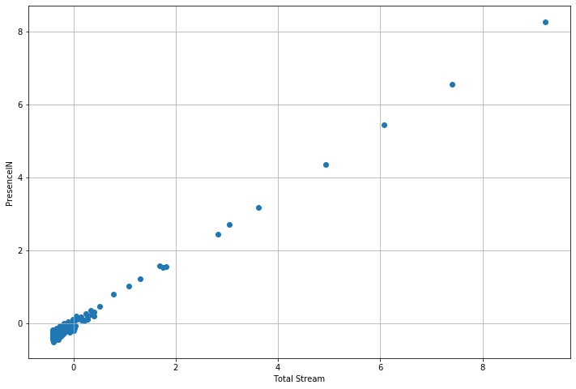

```python
plt.figure(figsize=(12,8))
plt.scatter( x_test.iloc[:, 0], y_test_preds)

plt.xlabel('Total Stream')
plt.ylabel('PresenceIN')

plt.grid()
plt.show()
```

```python
normalized_dataset[['Total Stream', 'PresenceIN']].corr()
```

|  | Total Stream | PresenceIN |
| --- | --- | --- |
| Total Stream | 1.000000 | 0.876387 |
| PresenceIN | 0.876387 | 1.000000 |

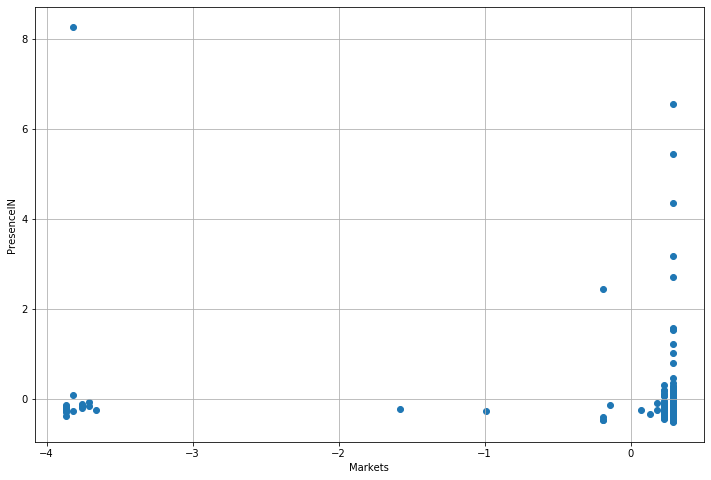

```python
plt.figure(figsize=(12,8))
plt.scatter( x_test.iloc[:, 3], y_test_preds)

plt.xlabel('Markets')
plt.ylabel('PresenceIN')

plt.grid()
plt.show()
```

```python
normalized_dataset[['Markets', 'PresenceIN']].corr()
```

|  | Markets | PresenceIN |
| --- | --- | --- |
| Markets | 1.000000 | 0.036196 |
| PresenceIN | 0.036196 | 1.000000 |

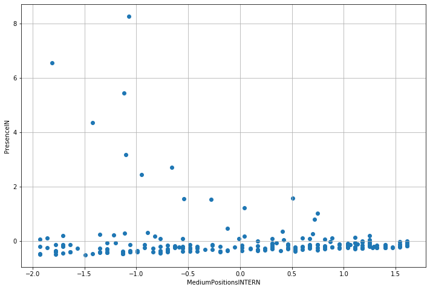

```python
plt.figure(figsize=(12,8))
plt.scatter( x_test.iloc[:, 1], y_test_preds)

plt.xlabel('MediumPositionsINTERN')
plt.ylabel('PresenceIN')

plt.grid()
plt.show()
```

```python
normalized_dataset[['MediumPositionsINTERN', 'PresenceIN']].corr()
```

|  | MediumPositionsINTERN | PresenceIN |
| --- | --- | --- |
| MediumPositionsINTERN | 1.000000 | -0.074316 |
| PresenceIN | -0.074316 | 1.000000 |

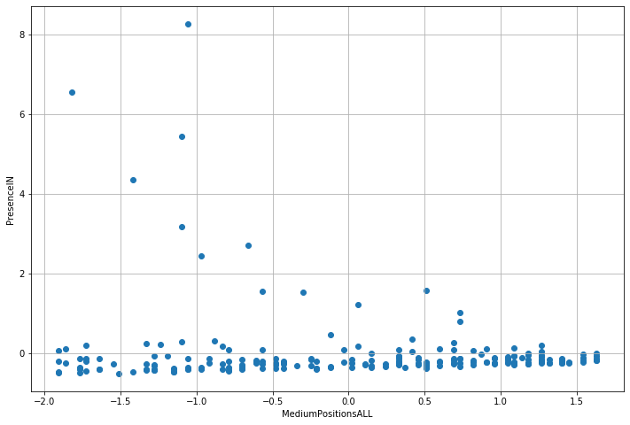

```python
plt.figure(figsize=(12,8))
plt.scatter( x_test.iloc[:, 2], y_test_preds)

plt.xlabel('MediumPositionsALL')
plt.ylabel('PresenceIN')

plt.grid()
plt.show()
```

```python
normalized_dataset[['MediumPositionsALL', 'PresenceIN']].corr()
```

|  | MediumPositionsALL | PresenceIN |
| --- | --- | --- |
| MediumPositionsALL | 1.000000 | -0.073866 |
| PresenceIN | -0.073866 | 1.000000 |

il **MAE (Mean Absolute Error)** misura quanto è imperfetta la misura da noi ottenuta. il MAE è la distanza verticale media tra ciascun punto e la linea di regressione. Nel caso in cui abbiamo buone misure, il segmento sarà relativamente piccolo.

Questi segmenti sono anche chiamati **residui**.

il risultato che otteniamo mostra effettivamente che il tasso di errore è relativamente basso e che non siamo in presenza di overfitting.

```python
def MAE(y_true, y_pred):
    return (y_true-y_pred).abs().mean()

print("MAE on the training set: {}".format(MAE(y_train,y_train_preds)))
print("MAE on the test set: {}".format(MAE(y_test,y_test_preds)))
```

[output not shown]

risulta essere interessante anche analizzare come variabile di risposta, Total Stream e predire il suo valore con la tecnica di regressione appena utilizzata.

```python
normalized_dataset_train, normalized_dataset_test = train_test_split(normalized_dataset, test_size = 0.20)

X = normalized_dataset.drop(['Song','Artist','Genre','Total Stream'], axis = 1)
Y = normalized_dataset[['Total Stream']]

x_train, x_test, y_train, y_test = train_test_split(X,Y, test_size = 0.20, random_state = 0)
print(x_train.shape, x_test.shape, y_train.shape, y_test.shape) #see the datasets dimension
```

```
(861, 4) (216, 4) (861, 1) (216, 1)
```

```python
reg = LinearRegression()
reg = reg.fit(x_train, y_train)

print(reg.coef_)
print(reg.intercept_)
```

```
[[ 0.82774281 -0.93744815  0.84908258  0.01123131]]
[-0.00674557]
```

```python
y_test_preds = reg.predict(x_test)
y_train_preds = reg.predict(x_train)

#only to display the dataframe.
y_dtest_preds = pd.DataFrame({'TotalStream_predicts': y_test_preds[:, 0]})
y_dtest_preds.head(10) #display only 10 rows
```

|  | TotalStream_predicts |
| --- | --- |
| 0 | -0.190584 |
| 1 | 1.527195 |
| 2 | -0.189910 |
| 3 | -0.123988 |
| 4 | -0.189910 |
| 5 | -0.414653 |
| 6 | -0.320136 |
| 7 | -0.091824 |
| 8 | -0.372695 |
| 9 | -0.232502 |

```python
x_test.head(10) #display only 10 rows
```

|  | MediumPositionsINTERN | MediumPositionsALL | PresenceIN | Markets |
| --- | --- | --- | --- | --- |
| 391 | -0.70 | -0.70 | -0.31 | 0.23 |
| 132 | 0.04 | 0.06 | 1.83 | 0.29 |
| 335 | -0.70 | -0.70 | -0.31 | 0.29 |
| 164 | -1.13 | -1.15 | -0.31 | 0.29 |
| 277 | -0.70 | -0.70 | -0.31 | 0.29 |
| 244 | 1.11 | 1.09 | -0.31 | -3.71 |
| 495 | 0.31 | 0.33 | -0.31 | 0.23 |
| 557 | 0.96 | 0.96 | 0.02 | 0.29 |
| 510 | 0.96 | 0.96 | -0.31 | 0.23 |
| 716 | -0.19 | -0.21 | -0.31 | -0.19 |

come fatto in precedenza, mostriamo i corrispettivi grafici tra la variabile di risposta (Total Stream) e le variabili indipendenti

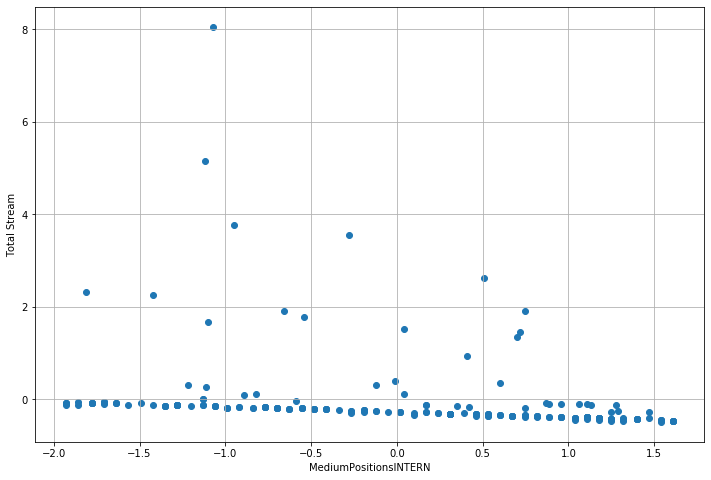

```python
plt.figure(figsize=(12,8))
plt.scatter( x_test.iloc[:, 0], y_test_preds)

plt.xlabel('MediumPositionsINTERN')
plt.ylabel('Total Stream')

plt.grid()
plt.show()
```

```python
normalized_dataset[['Total Stream', 'MediumPositionsINTERN']].corr()
```

|  | Total Stream | MediumPositionsINTERN |
| --- | --- | --- |
| Total Stream | 1.000000 | -0.179212 |
| MediumPositionsINTERN | -0.179212 | 1.000000 |

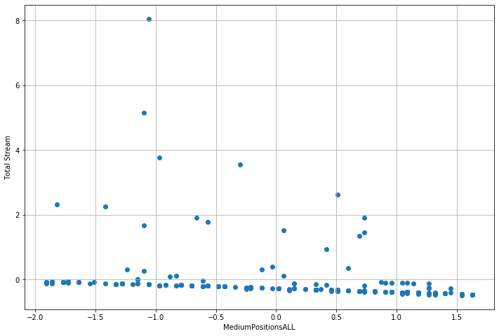

```python
plt.figure(figsize=(12,8))
plt.scatter( x_test.iloc[:, 1], y_test_preds)

plt.xlabel('MediumPositionsALL')
plt.ylabel('Total Stream')

plt.grid()
plt.show()
```

```python
normalized_dataset[['Total Stream', 'MediumPositionsALL']].corr()
```

|  | Total Stream | MediumPositionsALL |
| --- | --- | --- |
| Total Stream | 1.000000 | -0.178908 |
| MediumPositionsALL | -0.178908 | 1.000000 |

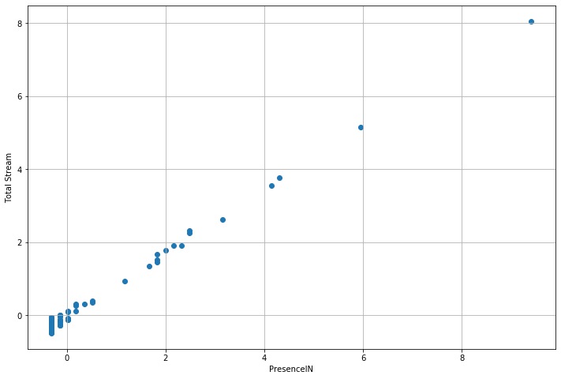

```python
plt.figure(figsize=(12,8))
plt.scatter( x_test.iloc[:, 2], y_test_preds)

plt.xlabel('PresenceIN')
plt.ylabel('Total Stream')

plt.grid()
plt.show()
```

```python
normalized_dataset[['Total Stream', 'PresenceIN']].corr()
```

|  | Total Stream | PresenceIN |
| --- | --- | --- |
| Total Stream | 1.000000 | 0.876387 |
| PresenceIN | 0.876387 | 1.000000 |

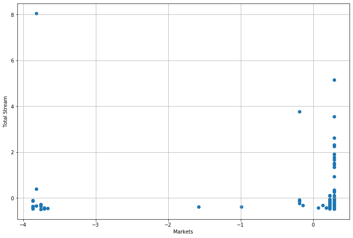

```python
plt.figure(figsize=(12,8))
plt.scatter( x_test.iloc[:, 3], y_test_preds)

plt.xlabel('Markets')
plt.ylabel('Total Stream')

plt.grid()
plt.show()
```

```python
normalized_dataset[['Total Stream', 'Markets']].corr()
```

|  | Total Stream | Markets |
| --- | --- | --- |
| Total Stream | 1.000000 | 0.029717 |
| Markets | 0.029717 | 1.000000 |

# Considerazioni e Conclusioni

- informazioni relative ad un **album**
- informazioni relative ad un'**artista**
- informazioni relative ad una **playlist**
- informazioni relative ad un **profilo utente**

D'altronde qualche dato non è possibile ottenerlo direttamente tramite API, infatti il dato stream non è stato possibile ottenerlo tramite richiesta API, per questioni di sicurezza riguardo le caratteristiche generali di una traccia.

Per concludere, Spotify fornisce tre tool abbastanza utili per la creazione di un progetto che utilizza questa API, come:

- **Audio Analysis**, vengono riportate analisi **profonde** sull'audio di una traccia. Si riportano le cosidette **"sections"** di una traccia, ovvero, analisi effettuate su una parte (non-omonegenea) di una traccia in cui viene indicato l'inizio dell'analisi, la fine dell'analisi, il rumore, la chiave, i BPM ecc.. All'interno di ciascuna section, vengono inserite altre informazioni ancora più dettagliate come: Bars, Beats, Tatums e i Segments che restringono il campo di analisi della traccia. Tutto assume un "andamento ad imbuto" poichè i bars a loro volta contengono i beats, tatums e i segmenti e cosi via fino ad arrivare alla più piccola parte di analisi audio che tratta pochi secondi della canzone.

[figure not shown]

- **Audio Features**, vengono riportate **dodici principali caratteristiche** di informazioni relative all'analisi media-audio della traccia, conviene spesso utilizzare questo tipo di tool perchè risulta essere più impuntato ad elementi base di una traccia, quali: rumorisità, live, chiave di nota principale, ballabilità, energia trasmessa, presenza di parti acustiche, presenza di parti "parlate" e la modalità con cui una traccia è stata creata, ovvero, il tipo di scala in cui la melodia è stata arrangiata.
- **Recommendations**, viene generata una lista di tracce che posseggono caratteristiche simili in termini di audio features ad una traccia. Su spotify, è possibile vedere sotto una determinata playlist personale un "pool" di canzoni che possono piacere all'utente in base alle tracce che sono presenti nella sua playlist. Questo tool **genera**, quindi, un **sistema di raccomandazione** ad HOC.